# lab1

Miker

2021/9/16

# part1

**1. Generate 200 random values from the standard exponential distribution and store them in a vector exp.draws.1. Find the mean and standard deviation of exp.draws.1.**

```r
exp.draws.1<-rexp(n=200)
mean(exp.draws.1)
```

```
## [1] 1.063101
```

```r
sd(exp.draws.1)
```

```
## [1] 1.111738
```

```r
exp.draws.0.1<-rexp(n=200,rate = 0.1)
exp.draws.0.5<-rexp(n=200,rate = 0.5)
exp.draws.5<-rexp(n=200,rate = 1)
exp.draws.10<-rexp(n=200,rate = 10)
```

**3. The function plot() is the generic function in R for the visual display of data. hist() is a function that takes in and bins data as a side effect. To use this function, we must first specify what we’d like to plot.**  
**a. Use the hist() function to produce a histogram of your standard exponential distribution.**

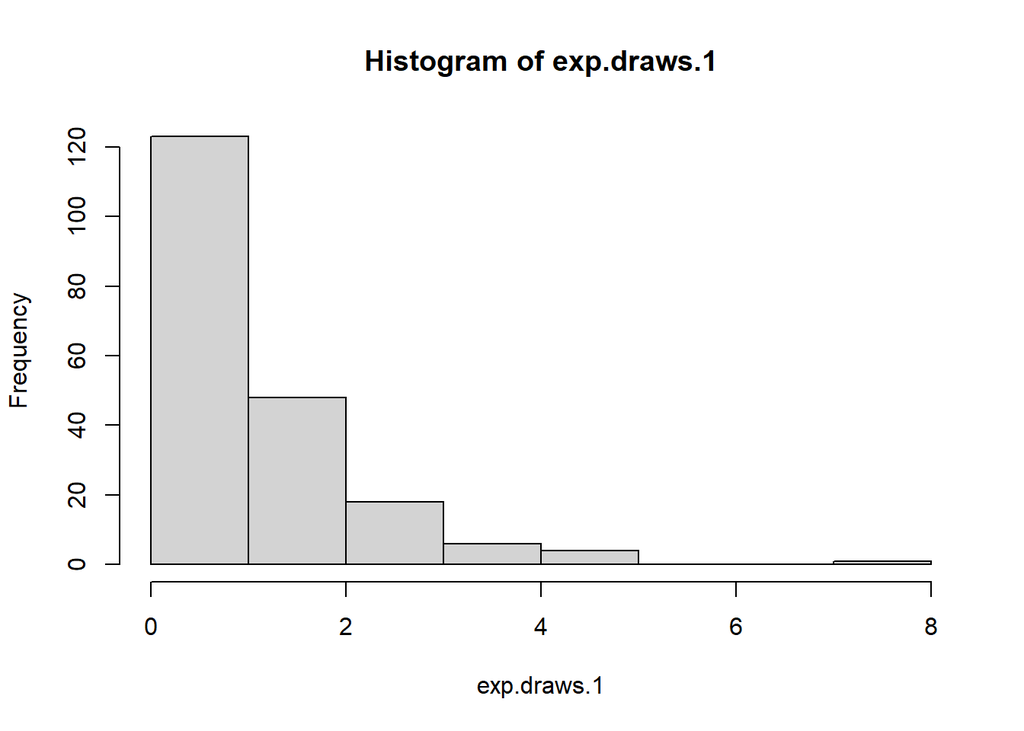

```r
hist(exp.draws.1)
```

**b. Use plot() with this vector to display the random values from your standard distribution in order.**

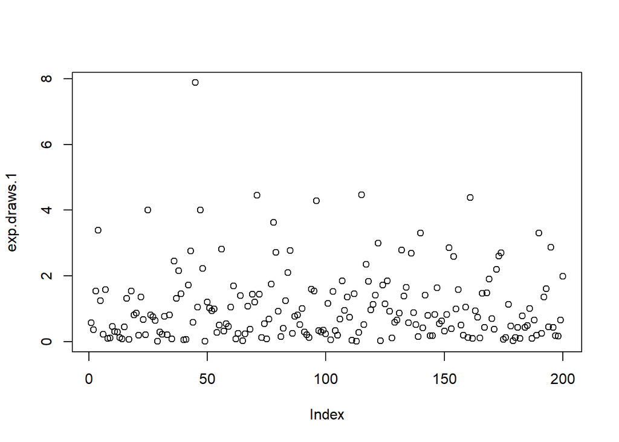

```r
plot(exp.draws.1)
```

**c. Now, use plot() with two arguments – any two of your other stored random value vectors – to create a scatterplot of the two vectors against each other.**

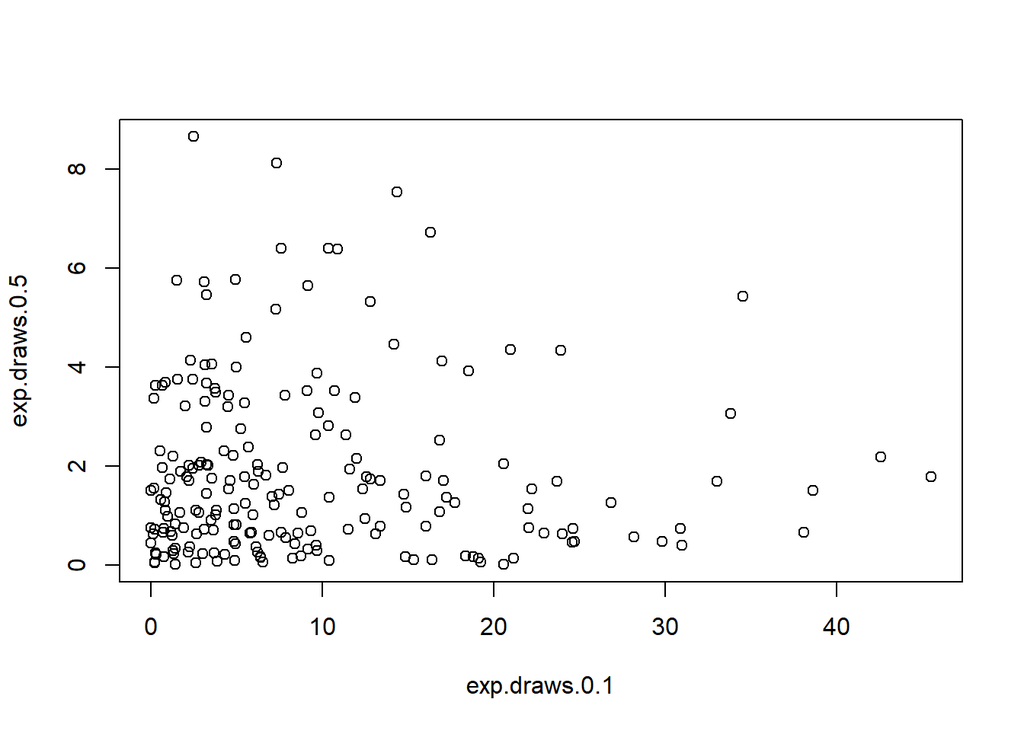

```r
plot(exp.draws.0.1,exp.draws.0.5)
```

**4. We’d now like to compare the properties of each of our vectors. Begin by creating a vector of the means of each of our five distributions in the order we created them and saving this to a variable name of your choice. Using this and other similar vectors, create the following scatterplots:**

```r
means<-c(mean(exp.draws.0.1),mean(exp.draws.0.5),mean(exp.draws.1),mean(exp.draws.5),mean(exp.draws.10))
```

**a. The five means versus the five rates used to generate the distribution.**

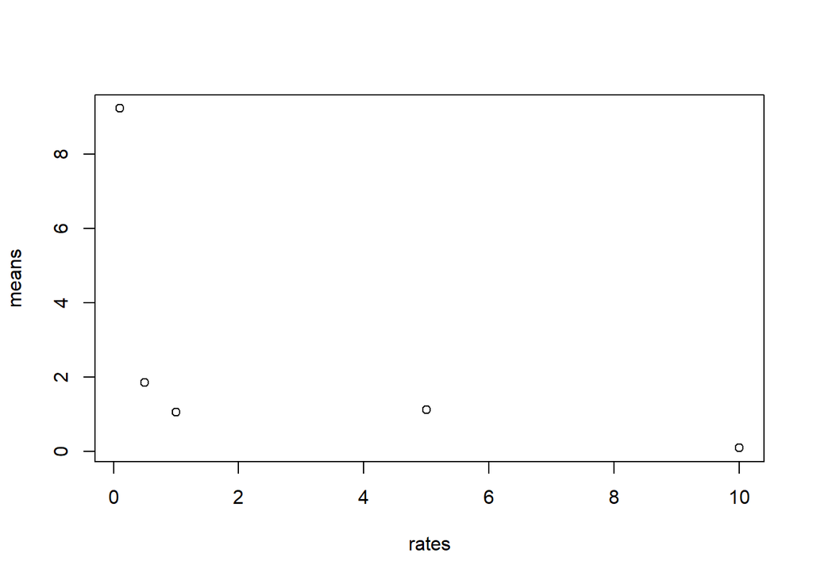

```r
rates<-c(0.1,0.5,1,5,10)
plot(rates,means)
```

**b. The standard deviations versus the rates.**

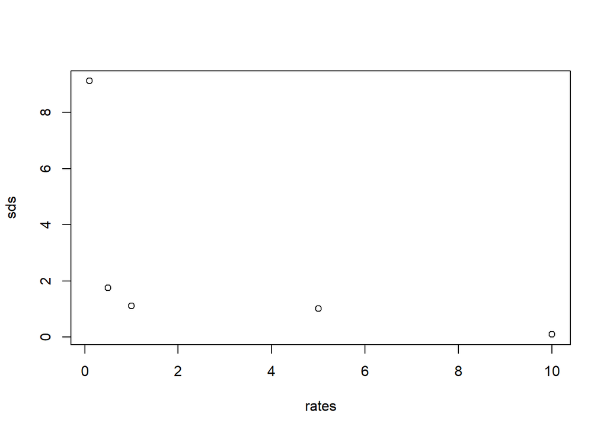

```r
sds<-c(sd(exp.draws.0.1),sd(exp.draws.0.5),sd(exp.draws.1),sd(exp.draws.5),sd(exp.draws.10))
plot(rates,sds)
```

**c. The means versus the standard deviations.**

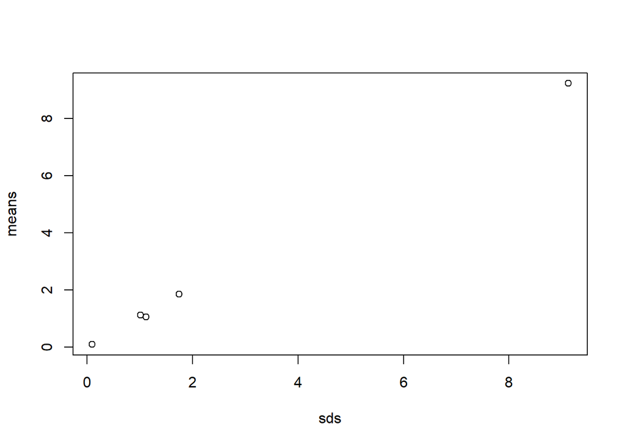

```r
plot(sds,means)
```

# part2  
**5. R’s capacity for data and computation is large to what was available 10 years ago.**  
**a. To show this, generate 1.1 million numbers from the standard exponential distribution and store them in a vector called big.exp.draws.1. Calculate the mean and standard deviation.**

```r
big.exp.draws.1<-rexp(n=1100000)
mean(big.exp.draws.1)
```

```
## [1] 0.9997642
```

```r
sd(big.exp.draws.1)
```

```
## [1] 1.000929
```

**b. Plot a histogram of big.exp.draws.1. Does it match the function 1 − e−x? Should it?**

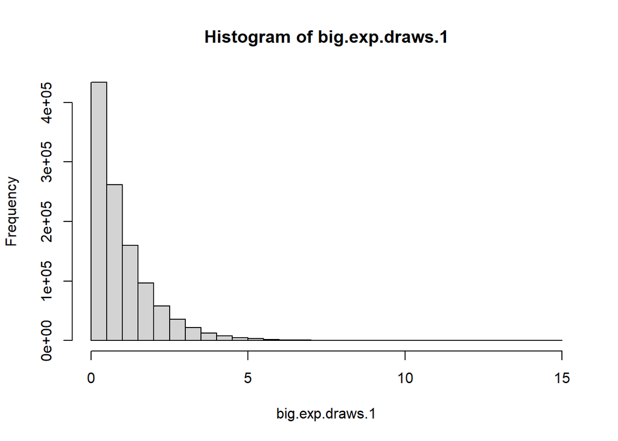

```r
hist(big.exp.draws.1)
```

不符合；不需要，需要符合1-exp(-x)的导数  
**c. Find the mean of all of the entries in big.exp.draws.1 which are strictly greater than 1. You may need to first create a new vector to identify which elements satisfy this.**

**d. Create a matrix, big.exp.draws.1.mat, containing the the values in big.exp.draws.1, with 1100 rows and 1000 columns. Use this matrix as the input to the hist() function and save the result to a variable of your choice. What happens to your data?**

**e. Calculate the mean of the 371st column of big.exp.draws.1.mat.**

**f. Now, find the means of all 1000 columns of big.exp.draws.1.mat simultaneously. Plot the histogram of column means. Explain why its shape does not match the histogram in problem 5b).**

**g. Take the square of each number in big.exp.draws.1, and find the mean of this new vector. Explain this in terms of the mean and standard deviation of big.exp.draws.1. Hint: think carefully about the formula R uses to calculate the standard deviation.**